# Simulation figures

Hanne Oberman

7-10-2021

# Data Generating Mechanism

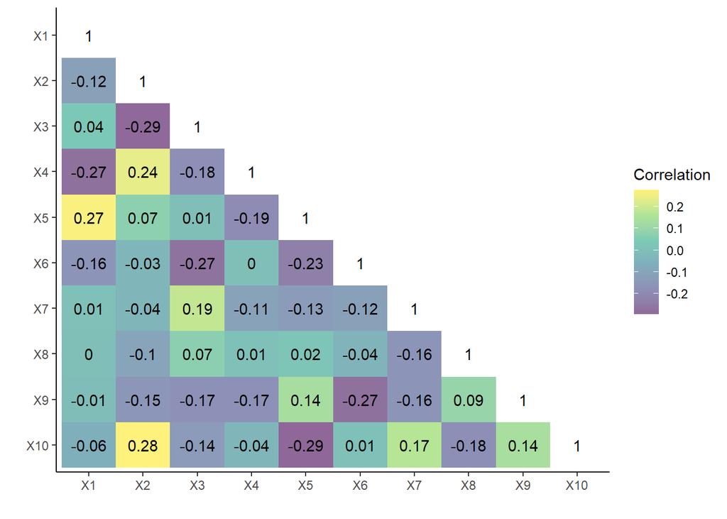

```r
# load data
corr <- readRDS("Data/correlations.RDS")
coef <- readRDS("Data/coefficients.RDS")
patt <- readRDS("Data/missing_data_pattern.RDS")

# plot
ggplot(corr, aes(x = pred, y = name, fill = value, label = text)) +
  geom_tile() +
  geom_text() +
  scale_x_discrete(limits = pred_lab) +
  scale_y_discrete(limits = rev(pred_lab)) +
  scale_fill_viridis_c(na.value = 0, alpha = .6, name = "Correlation") +
  labs(x = "", y = "") +
  theme_classic()
```

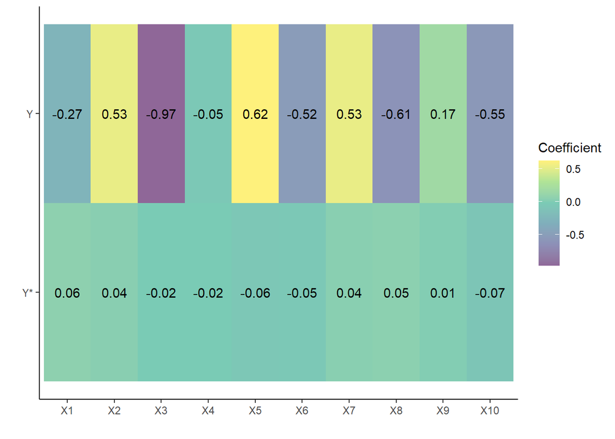

```r
ggplot(coef, aes(x = pred, y = type, fill = value, label = text)) +
  geom_tile() +
  geom_text() +
  scale_y_discrete(limits = c("Y*", "Y")) +
  scale_fill_viridis_c(na.value = 0, alpha = .6, name = "Coefficient") +
  labs(x = "", y = "") +
  theme_classic()
```

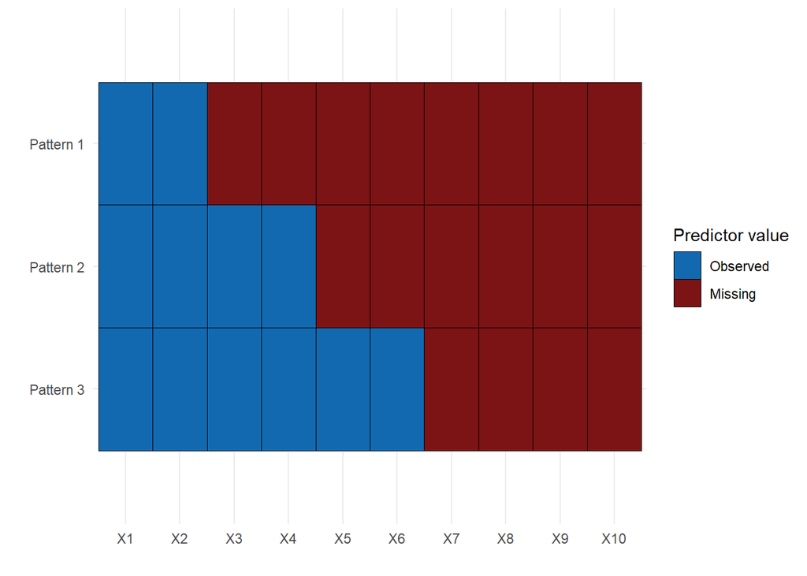

```r
ggplot(patt, aes(x = name, y = row, fill = value)) +
  geom_tile(color = "black") +
  scale_x_discrete(limits = pred_lab) +
  scale_y_discrete(limits = 1:3, labels = paste("Pattern", 3:1)) +
  scale_fill_manual(values = pred_col, name = "Predictor value") +
  labs(x = "", y = "") +
  theme_minimal()
```

# Reference Performance

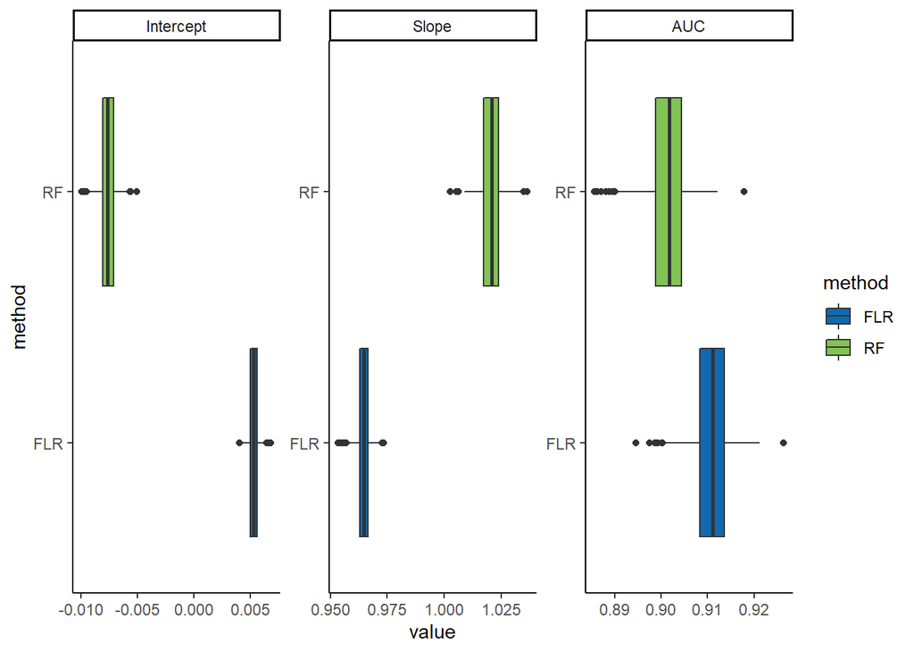

```r
# load data
ref_perf <- readRDS("Results/reference_performance.RDS")

# table
mean_ref <- ref_perf %>%
  group_by(method) %>%
  summarise(auc = mean(auc), int = mean(intercept), slo = mean(slope))

# plot
ref_perf %>% tidyr::pivot_longer(cols = everything()[-1]) %>%
  mutate(name = factor(name, levels = c("intercept", "slope", "auc"), labels = c( "Intercept", "Slope","AUC"), ordered = TRUE)) %>%
  ggplot(aes(x = value, y = method, fill = method)) +
  geom_boxplot() +
  facet_wrap(~name, scales = "free") +
  scale_fill_manual(values = meth_col) +
  theme_classic()
```

On complete data, the flexible logistics regression has slightly better performance than the random forest:

- FLR intercept closer to 0 than RF (0.005, -0.008, respectively);
- FLR slope *not* closer to 1 than RF (0.965, 1.021, respectively);
- FLR C-index higher than RF (0.911, 0.901, respectively).

# Simulation Results

```r
# load data
perf <- readRDS("Results/performance.RDS")

# plot function
plot_perf <- function(all_perf, metric = "RMSE"){
  all_perf[, c("Method", "Model", "Strategy", metric)] %>%
  setNames(c("Method", "Model", "Strategy", "metric")) %>%
  ggplot(aes(x = metric, y = Method, fill = Model)) +
  geom_boxplot() +
  scale_y_discrete(limits = rev(meth_lab), labels = plot_lab) +
  scale_fill_manual(values = meth_col) +
  theme_classic() +
  labs(x = metric, y = "Missing data strategy")
}
```

## Calibration

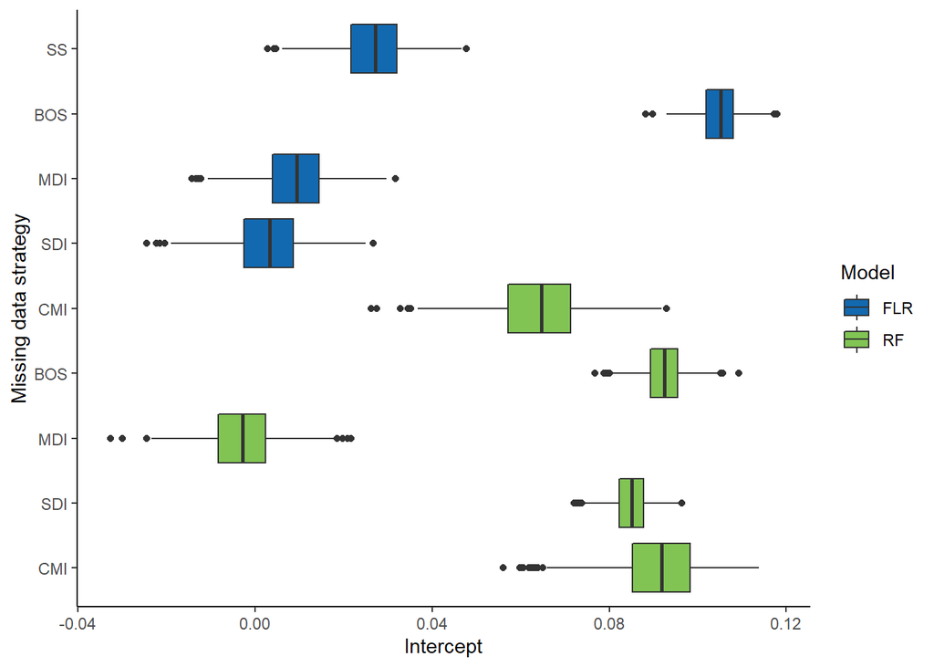

```r
plot_perf(perf, "Intercept")
```

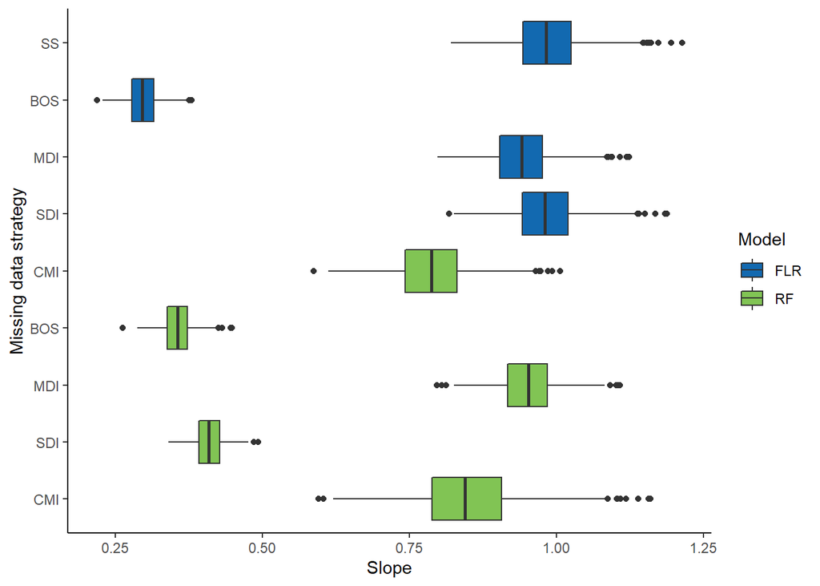

```r
plot_perf(perf, "Slope")
```

Aim: Intercept should be zero, slope should be one.

Summary:

- Best performance in terms of intercept: BOS+FLR, MDI+RF and MDI+FLR
- Worst performance in terms of intercept: SDI+FLR, SDI+RF, BOS+RF, SS+RF
- Best performance in terms of slope: BOS+FLR, CMI+FLR, MDI+RF and MDI+FLR
- Terrible performance in terms of slope: SDI+FLR, SDI+RF, BOS+RF (SS+RF = mixed bag)

## RMSE

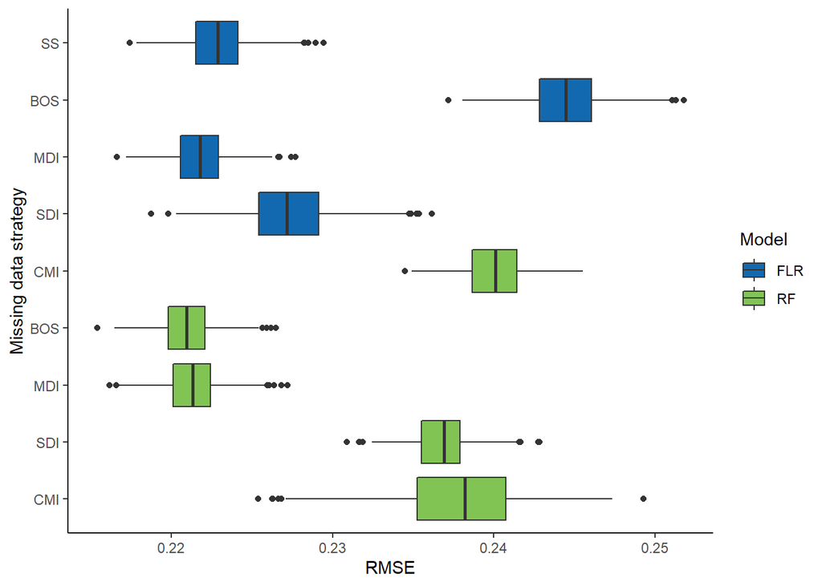

```r
plot_perf(perf, "RMSE")
```

Aim: As close to zero as possible. Method with the lowest RMSE has best recovered the original probability of Y.

## Brier score

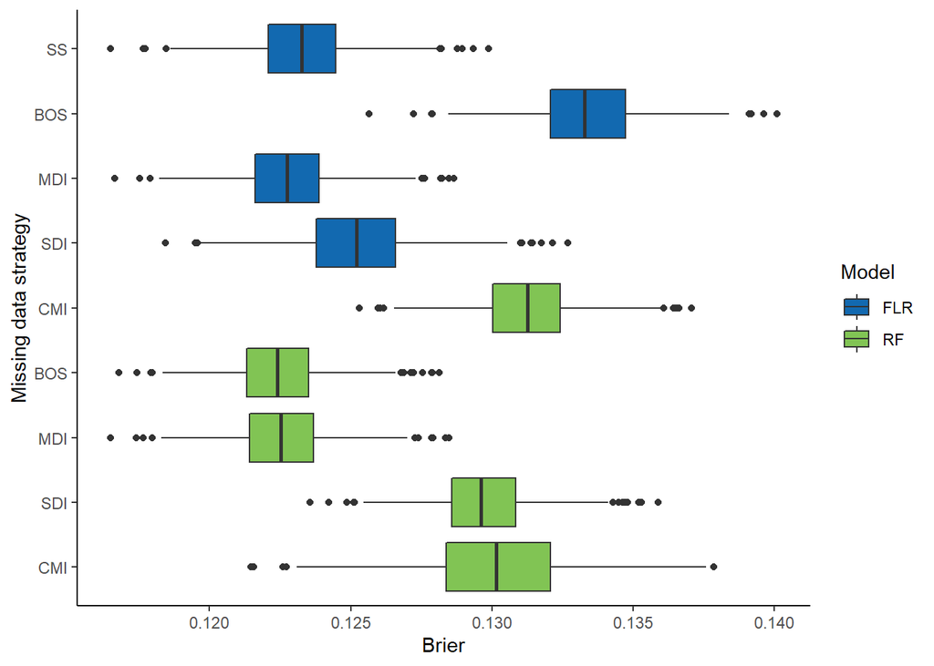

```r
plot_perf(perf, "Brier")
```

Aim: As close to zero as possible. Method with the lowest Brier score has best recovered the original observed Y.

## AUC

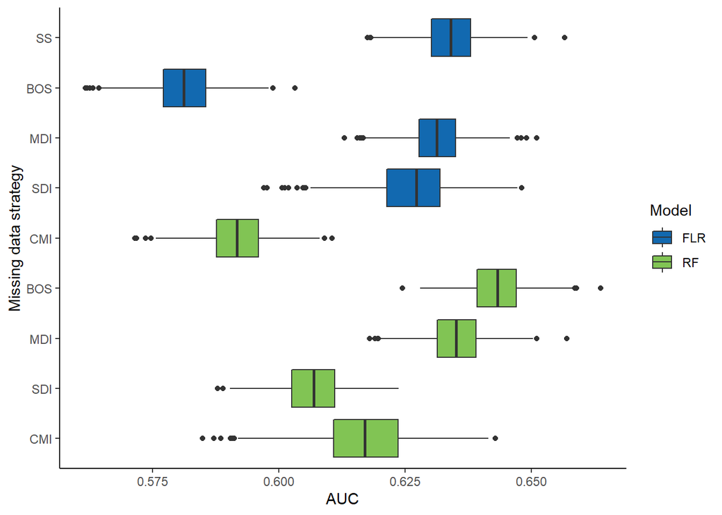

```r
plot_perf(perf, "AUC")
```

Aim: As close to one as possible. Method with the highest AUC has the best discrimination between patients with and without the outcome (Y).

## Full results

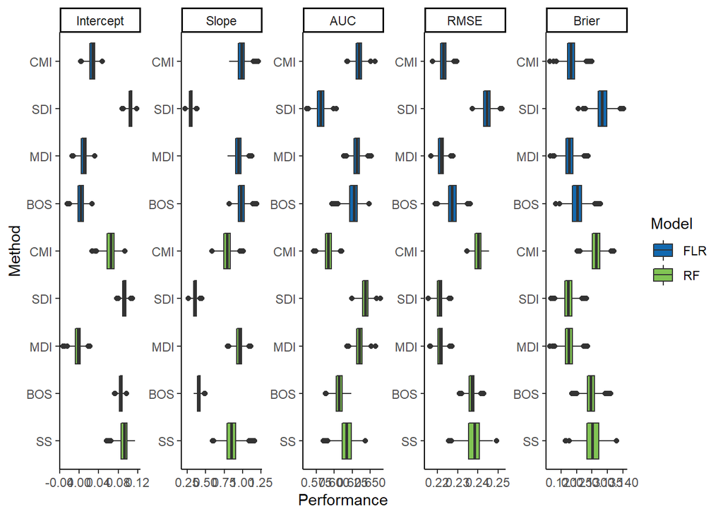

```r
# make wide format long
perf_long <- perf %>%
  tidyr::pivot_longer(cols = everything()[-c(1, 7, 8)], names_to = "Metric", values_to = "Performance") %>%
  mutate(
    Metric = factor(Metric, levels = c("Intercept", "Slope", "AUC", "RMSE", "Brier"), ordered = TRUE)
    )

# plot
ggplot(perf_long, aes(y = Method, x = Performance, fill = Model)) +
  geom_boxplot() +
  scale_y_discrete(limits = rev(meth_lab), labels = rev(c(miss_lab[-5], miss_lab))) +
  facet_wrap(~Metric, scales = "free", nrow = 1) +
  scale_fill_manual(values = meth_col) +
  theme_classic()
```

# Table

## Average performance

```r
(perf_table <- perf %>%
  select(-Method) %>%
  group_by(Model, Strategy) %>%
  summarise(across(everything(), mean),
            across(everything(), round, 3)))
```

```
## # A tibble: 10 x 7
## # Groups:   Model [2]
##    Model Strategy Intercept  Slope    AUC   RMSE  Brier
##    <chr> <ord>        <dbl>  <dbl>  <dbl>  <dbl>  <dbl>
##  1 FLR   CMI          0.027  0.984  0.634  0.223  0.123
##  2 FLR   SDI          0.105  0.297  0.581  0.244  0.133
##  3 FLR   MDI          0.009  0.94   0.631  0.222  0.123
##  4 FLR   BOS          0.003  0.981  0.627  0.227  0.125
##  5 FLR   SS          NA     NA     NA     NA     NA
##  6 RF    CMI          0.064  0.788  0.592  0.24   0.131
##  7 RF    SDI          0.092  0.355  0.643  0.221  0.122
##  8 RF    MDI         -0.003  0.951  0.635  0.221  0.123
##  9 RF    BOS          0.085  0.41   0.607  0.237  0.13
## 10 RF    SS           0.091  0.849  0.617  0.238  0.13
```

```r
perf_table %>%
   write.table(file = "Results/perf.csv", sep = ";", row.names = FALSE)

# kableExtra::kable(perf_table,
#                   format = "latex",
#                   booktabs = TRUE,
#                   align = c("l", "l", rep("c", 5)),
# )
```